# Analysis of Intervention

### Оценим bsts модель с трендом и сезонной компонентой.

$$\tau_{t+1}=-\sum_{i=1}^{S-1}\tau_i+\eta_{2t}$$
Компонента тренда обычна для локального уровня, но она содержит экстра параметр $\delta_t$. Заметим, что $\delta_t$ это ао сколько раз параметр $\mu$ увеличится или уменьшится при переходе $t→t+1$ , т.е. он может быть интерпретирован как напклон локального линейного тренда. Таким образом наклон следует модели случайного блуждания.

```r
library(bsts)     # load the bsts package
ss <- AddLocalLinearTrend(list(), iclaims[,2])
ss <- AddSeasonal(ss, iclaims[,2], nseasons = 52)
model1 <- bsts(iclaims[,2],
               state.specification = ss,
               niter = 1000)
```

[output not shown]

Существует несколько методов графической выдачи результатов

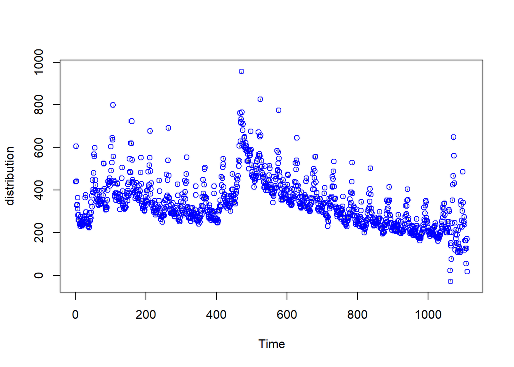

```r
plot(model1)
```

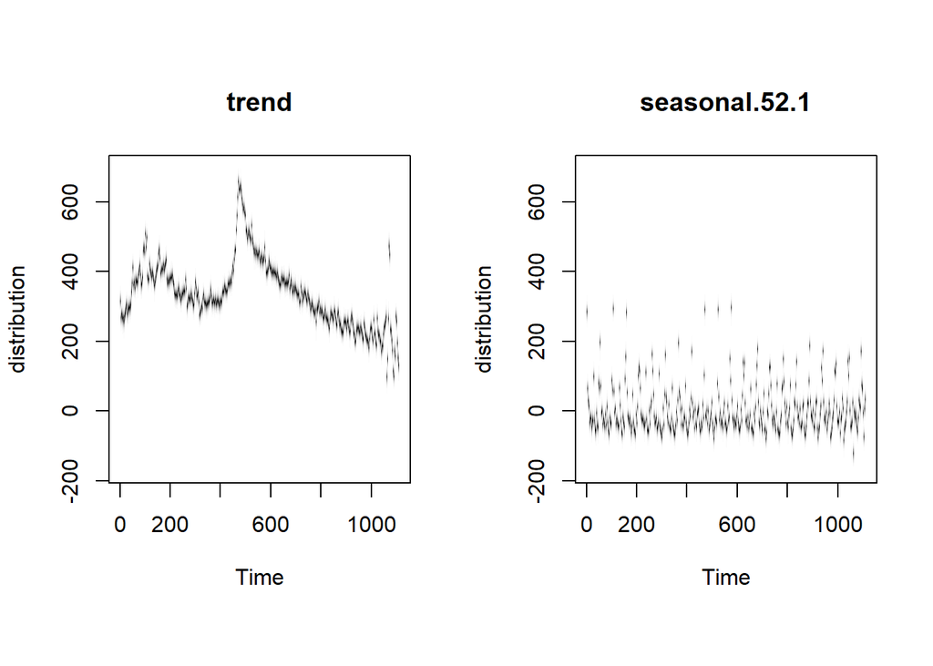

```r
plot(model1, "components")  # plot(model1, "comp") works too!
```

```r
#plot(model1, "help")
```

Для прогнозирования есть `predict()` method. Например для прогноза на следующих 12 моментов времени возможны следующие команды.

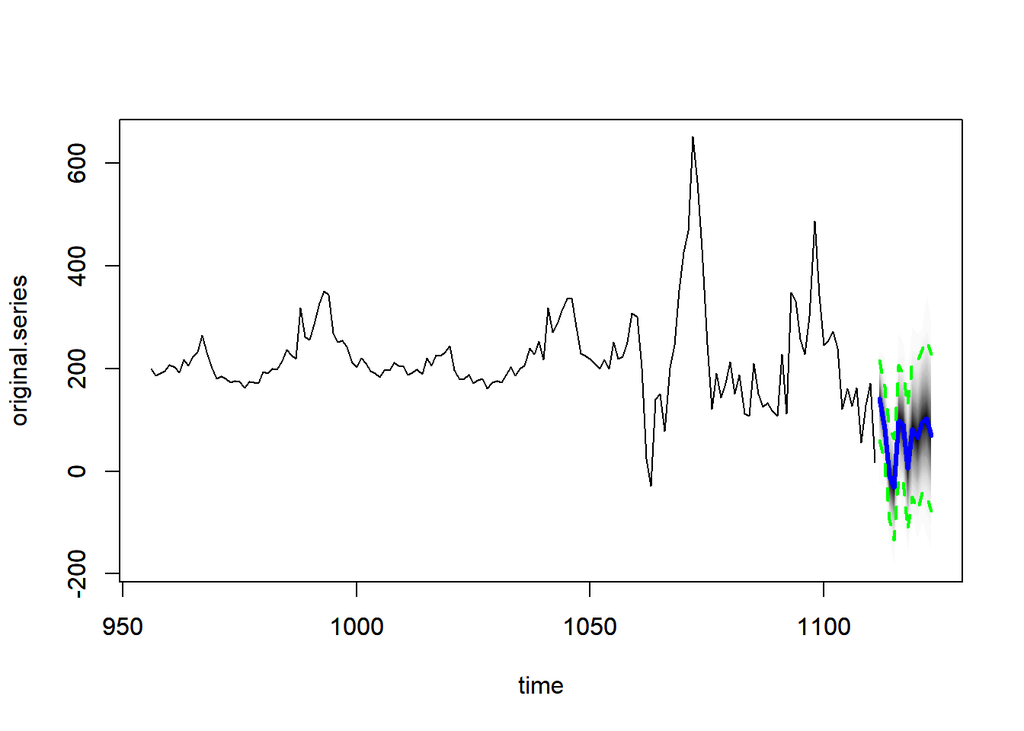

```r
pred1 <- predict(model1, horizon = 12)
plot(pred1, plot.original = 156)
```

```r
horizon <- 12
plot.original <- 156
original.series <- pred1$original.series
inter.horizon <-plot.original+horizon
original.series <- tail(original.series, plot.original)
```

Определим количество наблюдений, где интервенция присутствует.

```r
original.date   <- tail(iclaims[,1], plot.original)
(int.time <- which(original.date==Intervention.Time ))
```

```
## [1] 101
```

Смоделируем определенное выше наблюдений интервенции

```r
intr<-  inter.sim(inter.horizon,u0,ar,ma,int.time,isPulse= F)
```

Добавим иодель интервенции к оригинальным данным

```r
original.series <- original.series+head(intr,plot.original)
```

Добавим модель интервенции к прогнозам доверительных интервалов

```r
n1 <- ncol(pred1$distribution)
intr.forecast <- tail(intr,horizon)
for (i in 1:n1)
   pred1$distribution[,i]<- pred1$distribution[,i]+intr.forecast[i]
```

Зададим уровень доверия.

```r
interval.quantiles <- c(0.05,0.95)
pred1$interval <- apply(pred1$distribution, 2,
                             quantile, interval.quantiles)

ylim <- range(pred1$distribution, original.series,
              na.rm = TRUE)

time <- index(original.series)
deltat <- tail(diff(tail(time, 2)), 1)
pred.time <- tail(time, 1) + (1:n1) * deltat
```

Зададим параметры выдачи

```r
median.color <- "blue"
median.type <- 1
median.width <- 3
interval.type <- 3
interval.width <- 3
interval.color <- 'green'
median <- pred1$median + intr.forecast
median
```

```
##  [1] 737.4452 677.7588 585.9669 562.7005 693.5485 686.4822 600.2811 677.9010
##  [9] 659.5512 690.9515 698.2131 663.9401
```

Изобразим графически оригинальные данныеs, медиану и доверительные интервалы

```r
plot(time, original.series, type = "l",main='Initial claims forecasts', xlim = range(time,
                        pred.time, na.rm = TRUE), ylim = ylim)
PlotDynamicDistribution(curves = pred1$distribution,
                        timestamps = pred.time, add =  plot.original, ylim = ylim)
```

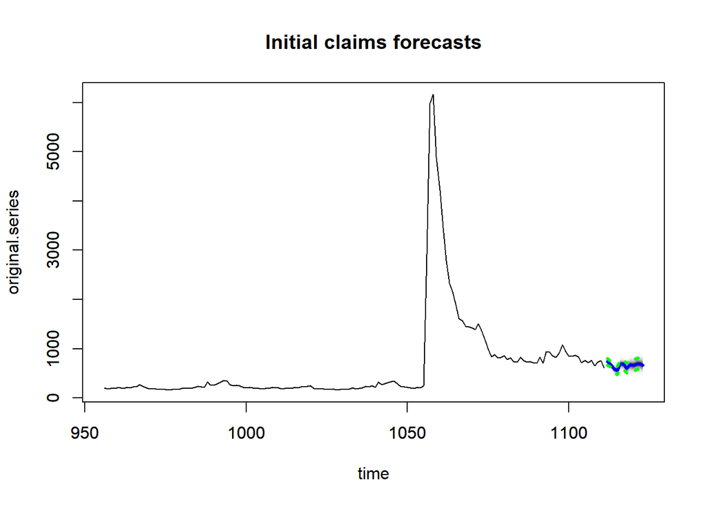

```r
lines(pred.time, median, col = median.color,
      lty = median.type, lwd = median.width)
for (i in 1:nrow(pred1$interval)) {
  lines(pred.time,  pred1$interval[i, ], col = interval.color,
        lty = interval.type, lwd = interval.width)
}
```